# eControl Met +: Study about the results of the addition of a sulfonylurea, DPP4 inhibitors or SGLT2 inhibitors as a second antidiabetic drug in patients with diabetes mellitus type 2 in treatment with

### Resultado 3.2. Comparativo

Estimaciones en relación a un grupo de referencia (IDPP4) crudo y ajustado

| datos | type | categoria | outcome | estimate | std.error | Linf | Lsup | p.value | Std_Coefficient | CIStd_low | CIStd_high |
| --- | --- | --- | --- | --- | --- | --- | --- | --- | --- | --- | --- |
| Imputados | Adjusted | grupISGLT2 | COLHDL.valor | 1.516 | 1.182 | -1.235 | 4.266 | 0.214 | 0.059 | -0.021 | 0.138 |
| Imputados | Adjusted | grupSU | COLHDL.valor | 0.088 | 1.161 | -2.613 | 2.788 | 0.940 | 0.003 | -0.076 | 0.083 |
| Imputados | Adjusted | grup.Ref | COLHDL.valor | 0.000 | NA | NA | NA | NA | NA | NA | NA |
| Imputados | Crudas | grupISGLT2 | COLHDL.valor | 1.188 | 1.205 | -1.615 | 3.992 | 0.330 | 0.046 | -0.038 | 0.130 |
| Imputados | Crudas | grupSU | COLHDL.valor | 0.130 | 1.242 | -2.760 | 3.019 | 0.918 | 0.005 | -0.079 | 0.089 |
| Imputados | Crudas | grup.Ref | COLHDL.valor | 0.000 | NA | NA | NA | NA | NA | NA | NA |
| Completos | Adjusted | grupISGLT2 | COLHDL.valor | 1.679 | 1.133 | -0.957 | 4.314 | 0.139 | 0.064 | -0.037 | 0.165 |
| Completos | Adjusted | grupSU | COLHDL.valor | 0.121 | 1.163 | -2.585 | 2.827 | 0.917 | 0.005 | -0.096 | 0.105 |
| Completos | Adjusted | grup.Ref | COLHDL.valor | NA | NA | NA | NA | NA | NA | NA | NA |
| Completos | Crudas | grupISGLT2 | COLHDL.valor | 1.405 | 1.194 | -1.372 | 4.182 | 0.240 | 0.054 | -0.052 | 0.160 |
| Completos | Crudas | grupSU | COLHDL.valor | 0.350 | 1.228 | -2.506 | 3.207 | 0.776 | 0.013 | -0.093 | 0.119 |
| Completos | Crudas | grup.Ref | COLHDL.valor | NA | NA | NA | NA | NA | NA | NA | NA |
| Imputados | Adjusted | grupISGLT2 | COLLDL.valor | -5.529 | 3.024 | -12.563 | 1.505 | 0.068 | -0.075 | -0.155 | 0.005 |
| Imputados | Adjusted | grupSU | COLLDL.valor | 0.132 | 3.071 | -7.012 | 7.276 | 0.966 | 0.002 | -0.078 | 0.082 |
| Imputados | Adjusted | grup.Ref | COLLDL.valor | 0.000 | NA | NA | NA | NA | NA | NA | NA |
| Imputados | Crudas | grupISGLT2 | COLLDL.valor | -6.196 | 3.149 | -13.522 | 1.129 | 0.050 | -0.084 | -0.168 | -0.001 |
| Imputados | Crudas | grupSU | COLLDL.valor | 0.550 | 3.199 | -6.893 | 7.992 | 0.864 | 0.007 | -0.076 | 0.091 |
| Imputados | Crudas | grup.Ref | COLLDL.valor | 0.000 | NA | NA | NA | NA | NA | NA | NA |
| Completos | Adjusted | grupISGLT2 | COLLDL.valor | -3.128 | 3.150 | -10.456 | 4.201 | 0.321 | -0.044 | -0.146 | 0.059 |
| Completos | Adjusted | grupSU | COLLDL.valor | 2.480 | 3.234 | -5.044 | 10.004 | 0.443 | 0.034 | -0.068 | 0.136 |
| Completos | Adjusted | grup.Ref | COLLDL.valor | NA | NA | NA | NA | NA | NA | NA | NA |
| Completos | Crudas | grupISGLT2 | COLLDL.valor | -4.176 | 3.267 | -11.776 | 3.424 | 0.202 | -0.058 | -0.164 | 0.048 |
| Completos | Crudas | grupSU | COLLDL.valor | 2.208 | 3.360 | -5.609 | 10.025 | 0.511 | 0.030 | -0.076 | 0.136 |
| Completos | Crudas | grup.Ref | COLLDL.valor | NA | NA | NA | NA | NA | NA | NA | NA |
| Imputados | Adjusted | grupISGLT2 | COLTOT.valor | -4.804 | 3.766 | -13.566 | 3.958 | 0.204 | -0.054 | -0.134 | 0.026 |
| Imputados | Adjusted | grupSU | COLTOT.valor | 1.953 | 3.785 | -6.852 | 10.758 | 0.606 | 0.021 | -0.059 | 0.102 |
| Imputados | Adjusted | grup.Ref | COLTOT.valor | 0.000 | NA | NA | NA | NA | NA | NA | NA |
| Imputados | Crudas | grupISGLT2 | COLTOT.valor | -4.866 | 3.902 | -13.945 | 4.212 | 0.213 | -0.054 | -0.138 | 0.029 |
| Imputados | Crudas | grupSU | COLTOT.valor | 1.891 | 3.925 | -7.239 | 11.022 | 0.630 | 0.021 | -0.063 | 0.104 |
| Imputados | Crudas | grup.Ref | COLTOT.valor | 0.000 | NA | NA | NA | NA | NA | NA | NA |

[output cut: 66 more lines]

```
## [1] ""
```

Estimaciones del grupo IDPP4 en relación al resto

| datos | type | categoria | outcome | estimate | std.error | Linf | Lsup | p.value | Std_Coefficient | CIStd_low | CIStd_high |
| --- | --- | --- | --- | --- | --- | --- | --- | --- | --- | --- | --- |
| Imputados | Adjusted | grup_IDPP4 | COLHDL.valor | -0.831 | 1.040 | -3.251 | 1.589 | 0.435 | -0.032 | -0.101 | 0.037 |
| Imputados | Crudas | grup_IDPP4 | COLHDL.valor | -0.680 | 1.085 | -3.204 | 1.844 | 0.537 | -0.026 | -0.099 | 0.047 |
| Completos | Adjusted | grup_IDPP4 | COLHDL.valor | -0.939 | 0.988 | -3.238 | 1.360 | 0.342 | -0.036 | -0.123 | 0.052 |
| Completos | Crudas | grup_IDPP4 | COLHDL.valor | -0.907 | 1.044 | -3.336 | 1.522 | 0.385 | -0.035 | -0.127 | 0.058 |
| Imputados | Adjusted | grup_IDPP4 | COLLDL.valor | 2.814 | 2.627 | -3.296 | 8.925 | 0.284 | 0.038 | -0.032 | 0.108 |
| Imputados | Crudas | grup_IDPP4 | COLLDL.valor | 2.958 | 2.747 | -3.432 | 9.349 | 0.282 | 0.040 | -0.033 | 0.113 |
| Completos | Adjusted | grup_IDPP4 | COLLDL.valor | 0.466 | 2.751 | -5.933 | 6.866 | 0.865 | 0.006 | -0.082 | 0.095 |
| Completos | Crudas | grup_IDPP4 | COLLDL.valor | 1.160 | 2.864 | -5.503 | 7.823 | 0.686 | 0.016 | -0.076 | 0.109 |
| Imputados | Adjusted | grup_IDPP4 | COLTOT.valor | 1.564 | 3.277 | -6.059 | 9.187 | 0.634 | 0.017 | -0.052 | 0.087 |
| Imputados | Crudas | grup_IDPP4 | COLTOT.valor | 1.623 | 3.394 | -6.274 | 9.519 | 0.633 | 0.018 | -0.055 | 0.091 |
| Completos | Adjusted | grup_IDPP4 | COLTOT.valor | 1.657 | 3.221 | -5.836 | 9.149 | 0.607 | 0.019 | -0.065 | 0.102 |
| Completos | Crudas | grup_IDPP4 | COLTOT.valor | 1.793 | 3.360 | -6.024 | 9.610 | 0.594 | 0.020 | -0.067 | 0.108 |
| Imputados | Adjusted | grup_IDPP4 | TG.valor | 20.036 | 13.302 | -10.910 | 50.981 | 0.132 | 0.054 | -0.016 | 0.125 |
| Imputados | Crudas | grup_IDPP4 | TG.valor | 17.539 | 13.728 | -14.398 | 49.476 | 0.202 | 0.048 | -0.025 | 0.121 |
| Completos | Adjusted | grup_IDPP4 | TG.valor | 18.404 | 13.691 | -13.445 | 50.253 | 0.179 | 0.049 | -0.036 | 0.135 |
| Completos | Crudas | grup_IDPP4 | TG.valor | 17.389 | 14.114 | -15.445 | 50.223 | 0.218 | 0.047 | -0.041 | 0.135 |
| Imputados | Adjusted | grup_IDPP4 | COLHDL.dif324m | -0.235 | 0.991 | -2.540 | 2.070 | 0.814 | -0.010 | -0.083 | 0.063 |
| Imputados | Crudas | grup_IDPP4 | COLHDL.dif324m | -0.305 | 0.992 | -2.612 | 2.002 | 0.761 | -0.013 | -0.086 | 0.060 |
| Completos | Adjusted | grup_IDPP4 | COLHDL.dif324m | -0.682 | 0.822 | -2.594 | 1.231 | 0.407 | -0.041 | -0.156 | 0.074 |
| Completos | Crudas | grup_IDPP4 | COLHDL.dif324m | -0.928 | 0.826 | -2.849 | 0.994 | 0.262 | -0.056 | -0.171 | 0.060 |
| Imputados | Adjusted | grup_IDPP4 | COLLDL.dif324m | 0.435 | 2.796 | -6.070 | 6.939 | 0.876 | 0.006 | -0.067 | 0.079 |
| Imputados | Crudas | grup_IDPP4 | COLLDL.dif324m | 0.626 | 2.799 | -5.885 | 7.138 | 0.823 | 0.008 | -0.065 | 0.081 |
| Completos | Adjusted | grup_IDPP4 | COLLDL.dif324m | -5.306 | 3.198 | -12.745 | 2.134 | 0.098 | -0.082 | -0.197 | 0.033 |
| Completos | Crudas | grup_IDPP4 | COLLDL.dif324m | -4.456 | 3.205 | -11.913 | 3.001 | 0.165 | -0.069 | -0.184 | 0.046 |
| Imputados | Adjusted | grup_IDPP4 | COLTOT.dif324m | -0.528 | 3.772 | -9.303 | 8.248 | 0.889 | -0.006 | -0.079 | 0.068 |
| Imputados | Crudas | grup_IDPP4 | COLTOT.dif324m | -0.483 | 3.724 | -9.146 | 8.180 | 0.897 | -0.005 | -0.078 | 0.068 |
| Completos | Adjusted | grup_IDPP4 | COLTOT.dif324m | -2.254 | 3.794 | -11.080 | 6.572 | 0.553 | -0.027 | -0.130 | 0.077 |
| Completos | Crudas | grup_IDPP4 | COLTOT.dif324m | -1.257 | 3.820 | -10.143 | 7.629 | 0.742 | -0.015 | -0.119 | 0.090 |
| Imputados | Adjusted | grup_IDPP4 | TG.valor.dif324m | 9.379 | 15.064 | -25.666 | 44.424 | 0.539 | 0.026 | -0.047 | 0.099 |
| Imputados | Crudas | grup_IDPP4 | TG.valor.dif324m | 7.902 | 15.529 | -28.223 | 44.027 | 0.617 | 0.022 | -0.051 | 0.095 |
| Completos | Adjusted | grup_IDPP4 | TG.valor.dif324m | 6.206 | 13.122 | -24.321 | 36.733 | 0.636 | 0.022 | -0.084 | 0.128 |
| Completos | Crudas | grup_IDPP4 | TG.valor.dif324m | 9.933 | 13.177 | -20.721 | 40.587 | 0.451 | 0.034 | -0.072 | 0.141 |

```
## [1] ""
```

Estimaciones del grupo SUFUNUREA en relación al resto

| datos | type | categoria | outcome | estimate | std.error | Linf | Lsup | p.value | Std_Coefficient | CIStd_low | CIStd_high |
| --- | --- | --- | --- | --- | --- | --- | --- | --- | --- | --- | --- |
| Imputados | Adjusted | grup_SU | COLHDL.valor | -0.661 | 0.956 | -2.884 | 1.563 | 0.490 | -0.025 | -0.095 | 0.045 |
| Imputados | Crudas | grup_SU | COLHDL.valor | -0.465 | 1.023 | -2.843 | 1.914 | 0.650 | -0.018 | -0.091 | 0.055 |
| Completos | Adjusted | grup_SU | COLHDL.valor | -0.709 | 1.020 | -3.082 | 1.665 | 0.488 | -0.026 | -0.114 | 0.062 |
| Completos | Crudas | grup_SU | COLHDL.valor | -0.357 | 1.071 | -2.849 | 2.134 | 0.739 | -0.013 | -0.106 | 0.079 |
| Imputados | Adjusted | grup_SU | COLLDL.valor | 2.861 | 2.696 | -3.410 | 9.133 | 0.289 | 0.038 | -0.032 | 0.108 |
| Imputados | Crudas | grup_SU | COLLDL.valor | 3.648 | 2.792 | -2.848 | 10.144 | 0.192 | 0.049 | -0.024 | 0.122 |
| Completos | Adjusted | grup_SU | COLLDL.valor | 4.027 | 2.835 | -2.568 | 10.621 | 0.156 | 0.055 | -0.035 | 0.144 |
| Completos | Crudas | grup_SU | COLLDL.valor | 4.311 | 2.932 | -2.510 | 11.131 | 0.142 | 0.058 | -0.034 | 0.151 |
| Imputados | Adjusted | grup_SU | COLTOT.valor | 4.324 | 3.277 | -3.299 | 11.947 | 0.187 | 0.047 | -0.023 | 0.118 |
| Imputados | Crudas | grup_SU | COLTOT.valor | 4.325 | 3.401 | -3.586 | 12.235 | 0.204 | 0.047 | -0.026 | 0.120 |
| Completos | Adjusted | grup_SU | COLTOT.valor | 4.292 | 3.305 | -3.398 | 11.981 | 0.195 | 0.047 | -0.037 | 0.131 |
| Completos | Crudas | grup_SU | COLTOT.valor | 4.327 | 3.435 | -3.664 | 12.318 | 0.208 | 0.047 | -0.040 | 0.135 |
| Imputados | Adjusted | grup_SU | TG.valor | -15.411 | 13.713 | -47.313 | 16.492 | 0.262 | -0.041 | -0.112 | 0.030 |
| Imputados | Crudas | grup_SU | TG.valor | -21.928 | 14.138 | -54.817 | 10.962 | 0.122 | -0.058 | -0.131 | 0.015 |
| Completos | Adjusted | grup_SU | TG.valor | -13.473 | 14.094 | -46.260 | 19.315 | 0.339 | -0.035 | -0.121 | 0.051 |
| Completos | Crudas | grup_SU | TG.valor | -21.460 | 14.461 | -55.101 | 12.181 | 0.138 | -0.056 | -0.144 | 0.032 |
| Imputados | Adjusted | grup_SU | COLHDL.dif324m | 0.360 | 1.224 | -2.488 | 3.209 | 0.781 | 0.015 | -0.059 | 0.089 |
| Imputados | Crudas | grup_SU | COLHDL.dif324m | 0.565 | 1.155 | -2.121 | 3.251 | 0.641 | 0.023 | -0.050 | 0.096 |
| Completos | Adjusted | grup_SU | COLHDL.dif324m | 0.525 | 0.813 | -1.365 | 2.416 | 0.518 | 0.032 | -0.084 | 0.149 |
| Completos | Crudas | grup_SU | COLHDL.dif324m | 0.591 | 0.807 | -1.287 | 2.469 | 0.464 | 0.036 | -0.079 | 0.152 |
| Imputados | Adjusted | grup_SU | COLLDL.dif324m | 0.903 | 3.209 | -6.562 | 8.368 | 0.781 | 0.012 | -0.062 | 0.085 |
| Imputados | Crudas | grup_SU | COLLDL.dif324m | 0.999 | 3.075 | -6.154 | 8.153 | 0.747 | 0.013 | -0.060 | 0.086 |
| Completos | Adjusted | grup_SU | COLLDL.dif324m | 3.653 | 3.165 | -3.711 | 11.017 | 0.249 | 0.058 | -0.059 | 0.175 |
| Completos | Crudas | grup_SU | COLLDL.dif324m | 2.383 | 3.135 | -4.911 | 9.677 | 0.448 | 0.038 | -0.078 | 0.153 |
| Imputados | Adjusted | grup_SU | COLTOT.dif324m | 2.419 | 4.196 | -7.343 | 12.181 | 0.574 | 0.025 | -0.048 | 0.099 |
| Imputados | Crudas | grup_SU | COLTOT.dif324m | 2.077 | 4.090 | -7.437 | 11.591 | 0.619 | 0.022 | -0.051 | 0.095 |
| Completos | Adjusted | grup_SU | COLTOT.dif324m | 3.031 | 3.707 | -5.592 | 11.654 | 0.414 | 0.037 | -0.067 | 0.141 |
| Completos | Crudas | grup_SU | COLTOT.dif324m | 2.307 | 3.727 | -6.364 | 10.977 | 0.536 | 0.028 | -0.077 | 0.132 |
| Imputados | Adjusted | grup_SU | TG.valor.dif324m | -14.612 | 13.903 | -46.956 | 17.733 | 0.294 | -0.039 | -0.113 | 0.034 |
| Imputados | Crudas | grup_SU | TG.valor.dif324m | -17.149 | 14.014 | -49.750 | 15.453 | 0.222 | -0.046 | -0.119 | 0.027 |
| Completos | Adjusted | grup_SU | TG.valor.dif324m | -13.725 | 12.784 | -43.466 | 16.016 | 0.284 | -0.049 | -0.155 | 0.057 |
| Completos | Crudas | grup_SU | TG.valor.dif324m | -16.726 | 12.852 | -46.625 | 13.172 | 0.194 | -0.059 | -0.166 | 0.047 |

```
## [1] ""
```

Estimaciones del grupo ISGLT2 en relación al resto

| datos | type | categoria | outcome | estimate | std.error | Linf | Lsup | p.value | Std_Coefficient | CIStd_low | CIStd_high |
| --- | --- | --- | --- | --- | --- | --- | --- | --- | --- | --- | --- |
| Imputados | Adjusted | grup_ISGLT2 | COLHDL.valor | 1.474 | 0.977 | -0.798 | 3.747 | 0.136 | 0.057 | -0.013 | 0.127 |
| Imputados | Crudas | grup_ISGLT2 | COLHDL.valor | 1.126 | 0.990 | -1.177 | 3.429 | 0.257 | 0.044 | -0.029 | 0.116 |
| Completos | Adjusted | grup_ISGLT2 | COLHDL.valor | 1.622 | 0.992 | -0.686 | 3.930 | 0.103 | 0.062 | -0.026 | 0.150 |
| Completos | Crudas | grup_ISGLT2 | COLHDL.valor | 1.239 | 1.040 | -1.181 | 3.658 | 0.234 | 0.047 | -0.045 | 0.140 |
| Imputados | Adjusted | grup_ISGLT2 | COLLDL.valor | -5.592 | 2.648 | -11.752 | 0.569 | 0.035 | -0.076 | -0.146 | -0.006 |
| Imputados | Crudas | grup_ISGLT2 | COLLDL.valor | -6.460 | 2.741 | -12.837 | -0.084 | 0.019 | -0.088 | -0.161 | -0.015 |
| Completos | Adjusted | grup_ISGLT2 | COLLDL.valor | -4.291 | 2.760 | -10.712 | 2.130 | 0.121 | -0.060 | -0.149 | 0.030 |
| Completos | Crudas | grup_ISGLT2 | COLLDL.valor | -5.227 | 2.848 | -11.851 | 1.397 | 0.067 | -0.073 | -0.165 | 0.019 |
| Imputados | Adjusted | grup_ISGLT2 | COLTOT.valor | -5.728 | 3.259 | -13.309 | 1.853 | 0.080 | -0.064 | -0.134 | 0.006 |
| Imputados | Crudas | grup_ISGLT2 | COLTOT.valor | -5.774 | 3.378 | -13.634 | 2.085 | 0.088 | -0.065 | -0.137 | 0.008 |
| Completos | Adjusted | grup_ISGLT2 | COLTOT.valor | -5.796 | 3.234 | -13.320 | 1.728 | 0.074 | -0.065 | -0.149 | 0.019 |
| Completos | Crudas | grup_ISGLT2 | COLTOT.valor | -5.950 | 3.360 | -13.766 | 1.867 | 0.077 | -0.066 | -0.154 | 0.021 |
| Imputados | Adjusted | grup_ISGLT2 | TG.valor | -5.510 | 13.406 | -36.696 | 25.676 | 0.681 | -0.015 | -0.086 | 0.056 |
| Imputados | Crudas | grup_ISGLT2 | TG.valor | 3.511 | 13.785 | -28.558 | 35.581 | 0.799 | 0.010 | -0.064 | 0.083 |
| Completos | Adjusted | grup_ISGLT2 | TG.valor | -5.720 | 13.761 | -37.733 | 26.294 | 0.678 | -0.015 | -0.101 | 0.071 |
| Completos | Crudas | grup_ISGLT2 | TG.valor | 3.027 | 14.115 | -29.809 | 35.863 | 0.830 | 0.008 | -0.080 | 0.096 |
| Imputados | Adjusted | grup_ISGLT2 | COLHDL.dif324m | -0.107 | 0.953 | -2.323 | 2.109 | 0.911 | -0.005 | -0.078 | 0.069 |
| Imputados | Crudas | grup_ISGLT2 | COLHDL.dif324m | -0.237 | 0.919 | -2.374 | 1.900 | 0.797 | -0.010 | -0.083 | 0.063 |
| Completos | Adjusted | grup_ISGLT2 | COLHDL.dif324m | 0.132 | 0.787 | -1.700 | 1.963 | 0.867 | 0.008 | -0.108 | 0.125 |
| Completos | Crudas | grup_ISGLT2 | COLHDL.dif324m | 0.274 | 0.781 | -1.542 | 2.090 | 0.726 | 0.017 | -0.098 | 0.133 |
| Imputados | Adjusted | grup_ISGLT2 | COLLDL.dif324m | -1.306 | 3.144 | -8.620 | 6.008 | 0.682 | -0.017 | -0.091 | 0.056 |
| Imputados | Crudas | grup_ISGLT2 | COLLDL.dif324m | -1.586 | 3.046 | -8.671 | 5.499 | 0.606 | -0.021 | -0.094 | 0.052 |
| Completos | Adjusted | grup_ISGLT2 | COLLDL.dif324m | 1.432 | 3.070 | -5.710 | 8.574 | 0.641 | 0.023 | -0.094 | 0.141 |
| Completos | Crudas | grup_ISGLT2 | COLLDL.dif324m | 1.743 | 3.032 | -5.309 | 8.796 | 0.566 | 0.029 | -0.087 | 0.144 |
| Imputados | Adjusted | grup_ISGLT2 | COLTOT.dif324m | -1.785 | 3.568 | -10.086 | 6.516 | 0.617 | -0.019 | -0.093 | 0.055 |
| Imputados | Crudas | grup_ISGLT2 | COLTOT.dif324m | -1.511 | 3.535 | -9.734 | 6.713 | 0.669 | -0.016 | -0.089 | 0.057 |
| Completos | Adjusted | grup_ISGLT2 | COLTOT.dif324m | -0.839 | 3.626 | -9.273 | 7.596 | 0.817 | -0.010 | -0.115 | 0.094 |
| Completos | Crudas | grup_ISGLT2 | COLTOT.dif324m | -1.048 | 3.625 | -9.482 | 7.385 | 0.773 | -0.013 | -0.118 | 0.092 |
| Imputados | Adjusted | grup_ISGLT2 | TG.valor.dif324m | 4.512 | 14.850 | -30.034 | 39.058 | 0.763 | 0.012 | -0.061 | 0.085 |
| Imputados | Crudas | grup_ISGLT2 | TG.valor.dif324m | 8.561 | 14.628 | -25.470 | 42.591 | 0.561 | 0.023 | -0.050 | 0.096 |
| Completos | Adjusted | grup_ISGLT2 | TG.valor.dif324m | 7.415 | 12.457 | -21.565 | 36.395 | 0.552 | 0.027 | -0.079 | 0.134 |
| Completos | Crudas | grup_ISGLT2 | TG.valor.dif324m | 6.792 | 12.454 | -22.180 | 35.764 | 0.586 | 0.025 | -0.082 | 0.131 |

## Resultado 4 (Seguimiento de fármacos dispensados: MPR, adherencia y stops).

### Resultado 4.1. Descriptiva

- To assess the adherence to treatment after the addition of an SU, a DPP-4i or an SGLT-2i in patients with DM2 treated with metformin and insufficient glycemic control.

Summary descriptive tables

|  | Complete case Analysis [ALL] | Complete case Analysis IDPP4 | Complete case Analysis ISGLT2 | Complete case Analysis SU | Complete case Analysis N | Imputation cases analysis (m=10) [ALL] | Imputation cases analysis (m=10) IDPP4 | Imputation cases analysis (m=10) ISGLT2 | Imputation cases analysis (m=10) SU | Imputation cases analysis (m=10) N |
| --- | --- | --- | --- | --- | --- | --- | --- | --- | --- | --- |
|  | N=722 | N=247 | N=247 | N=228 |  | N=1444 | N=494 | N=494 | N=456 |  |
| Medication possession ratio, Mean (SD) | 0.71 (0.35) | 0.70 (0.34) | 0.79 (0.35) | 0.63 (0.34) | 721 | 0.72 (0.34) | 0.71 (0.33) | 0.81 (0.33) | 0.64 (0.34) | 1444 |
| Adherence (Good/Low): |  |  |  |  | 721 |  |  |  |  | 1444 |
| No | 325 (45.1%) | 116 (47.2%) | 74 (30.0%) | 135 (59.2%) |  | 635 (44.0%) | 231 (46.8%) | 137 (27.7%) | 267 (58.6%) |  |
| Yes | 396 (54.9%) | 130 (52.8%) | 173 (70.0%) | 93 (40.8%) |  | 809 (56.0%) | 263 (53.2%) | 357 (72.3%) | 189 (41.4%) |  |
| Envases del grupo de estudio, Mean (SD) | 11.1 (10.9) | 10.9 (8.54) | 12.0 (9.02) | 10.5 (14.4) | 722 | 11.3 (10.8) | 10.9 (8.49) | 12.3 (8.88) | 10.6 (14.4) | 1444 |

Summary descriptive tables

|  | Complete case Analysis [ALL] | Complete case Analysis IDPP4 | Complete case Analysis ISGLT2 | Complete case Analysis SU | Complete case Analysis N | Imputation cases analysis (m=10) [ALL] | Imputation cases analysis (m=10) IDPP4 | Imputation cases analysis (m=10) ISGLT2 | Imputation cases analysis (m=10) SU | Imputation cases analysis (m=10) N |
| --- | --- | --- | --- | --- | --- | --- | --- | --- | --- | --- |
|  | N=722 | N=247 | N=247 | N=228 |  | N=1444 | N=494 | N=494 | N=456 |  |
| Medication possession ratio, Median [25th;75th] | 0.94 [0.40;1.00] | 0.87 [0.43;1.00] | 1.00 [0.64;1.00] | 0.64 [0.32;1.00] | 721 | 0.96 [0.43;1.00] | 0.88 [0.44;1.00] | 1.00 [0.72;1.00] | 0.65 [0.33;1.00] | 1444 |
| Adherence (Good/Low): |  |  |  |  | 721 |  |  |  |  | 1444 |
| No | 325 (45.1%) | 116 (47.2%) | 74 (30.0%) | 135 (59.2%) |  | 635 (44.0%) | 231 (46.8%) | 137 (27.7%) | 267 (58.6%) |  |
| Yes | 396 (54.9%) | 130 (52.8%) | 173 (70.0%) | 93 (40.8%) |  | 809 (56.0%) | 263 (53.2%) | 357 (72.3%) | 189 (41.4%) |  |
| Envases del grupo de estudio, Median [25th;75th] | 8.27 [3.10;16.5] | 9.23 [3.10;17.5] | 11.2 [3.10;19.6] | 7.23 [3.10;13.4] | 722 | 9.17 [3.10;17.4] | 9.27 [3.10;17.5] | 11.3 [4.10;19.6] | 7.23 [3.10;13.4] | 1444 |

### Resultado 4.1. Comparativa

Estimaciones del de cada grupo en relqación a IDPP4 y resto, crudas y ajustadas

| datos | type | categoria | outcome | estimate | std.error | Linf | Lsup | p.value | Std_Coefficient | CIStd_low | CIStd_high | OR |
| --- | --- | --- | --- | --- | --- | --- | --- | --- | --- | --- | --- | --- |
| Imputados | Adjusted | grupISGLT2 | MPR.TX | 0.061 | 0.030 | -0.007 | 0.130 | 0.038 | 0.083 | 0.005 | 0.162 | NA |
| Imputados | Adjusted | grupSU | MPR.TX | -0.079 | 0.030 | -0.149 | -0.008 | 0.009 | -0.105 | -0.184 | -0.026 | NA |
| Imputados | Adjusted | grup.Ref | MPR.TX | 0.000 | NA | NA | NA | NA | NA | NA | NA | NA |
| Imputados | Crudas | grupISGLT2 | MPR.TX | 0.082 | 0.031 | 0.010 | 0.154 | 0.008 | 0.112 | 0.029 | 0.194 | NA |
| Imputados | Crudas | grupSU | MPR.TX | -0.075 | 0.032 | -0.149 | -0.002 | 0.017 | -0.101 | -0.183 | -0.018 | NA |
| Imputados | Crudas | grup.Ref | MPR.TX | 0.000 | NA | NA | NA | NA | NA | NA | NA | NA |
| Completos | Adjusted | grupISGLT2 | MPR.TX | 0.060 | 0.030 | -0.008 | 0.129 | 0.041 | 0.082 | -0.011 | 0.176 | NA |
| Completos | Adjusted | grupSU | MPR.TX | -0.079 | 0.030 | -0.149 | -0.009 | 0.009 | -0.106 | -0.199 | -0.012 | NA |
| Completos | Adjusted | grup.Ref | MPR.TX | NA | NA | NA | NA | NA | NA | NA | NA | NA |
| Completos | Crudas | grupISGLT2 | MPR.TX | 0.082 | 0.031 | 0.011 | 0.154 | 0.008 | 0.112 | 0.014 | 0.210 | NA |
| Completos | Crudas | grupSU | MPR.TX | -0.075 | 0.032 | -0.148 | -0.002 | 0.018 | -0.100 | -0.198 | -0.002 | NA |
| Completos | Crudas | grup.Ref | MPR.TX | NA | NA | NA | NA | NA | NA | NA | NA | NA |
| Imputados | Adjusted | grupISGLT2 | MPR.TX.cat | 0.625 | 0.203 | 1.164 | 2.999 | 0.002 | 0.297 | 0.073 | 0.520 | 1.868 |
| Imputados | Adjusted | grupSU | MPR.TX.cat | -0.620 | 0.205 | 0.334 | 0.866 | 0.003 | -0.288 | -0.508 | -0.068 | 0.538 |
| Imputados | Adjusted | grup.Ref | MPR.TX.cat | NA | NA | NA | NA | NA | NA | NA | NA | NA |
| Imputados | Crudas | grupISGLT2 | MPR.TX.cat | 0.736 | 0.189 | 1.344 | 3.240 | 0.000 | 0.349 | 0.141 | 0.557 | 2.087 |
| Imputados | Crudas | grupSU | MPR.TX.cat | -0.486 | 0.186 | 0.399 | 0.948 | 0.009 | -0.226 | -0.427 | -0.025 | 0.615 |
| Imputados | Crudas | grup.Ref | MPR.TX.cat | NA | NA | NA | NA | NA | NA | NA | NA | NA |
| Completos | Adjusted | grupISGLT2 | MPR.TX.cat | 0.614 | 0.203 | 1.154 | 2.961 | 0.002 | 0.292 | 0.068 | 0.516 | 1.848 |
| Completos | Adjusted | grupSU | MPR.TX.cat | -0.629 | 0.204 | 0.332 | 0.856 | 0.002 | -0.293 | -0.514 | -0.072 | 0.533 |
| Completos | Adjusted | grup.Ref | MPR.TX.cat | NA | NA | NA | NA | NA | NA | NA | NA | NA |
| Completos | Crudas | grupISGLT2 | MPR.TX.cat | 0.735 | 0.189 | 1.345 | 3.236 | 0.000 | 0.349 | 0.141 | 0.558 | 2.086 |
| Completos | Crudas | grupSU | MPR.TX.cat | -0.487 | 0.186 | 0.399 | 0.947 | 0.009 | -0.226 | -0.427 | -0.025 | 0.615 |
| Completos | Crudas | grup.Ref | MPR.TX.cat | NA | NA | NA | NA | NA | NA | NA | NA | NA |
| Imputados | Adjusted | grupISGLT2 | NenvasTX.GRUP | 0.727 | 0.915 | -1.403 | 2.856 | 0.428 | 0.032 | -0.047 | 0.110 | NA |
| Imputados | Adjusted | grupSU | NenvasTX.GRUP | -0.547 | 0.935 | -2.722 | 1.628 | 0.559 | -0.023 | -0.102 | 0.055 | NA |
| Imputados | Adjusted | grup.Ref | NenvasTX.GRUP | 0.000 | NA | NA | NA | NA | NA | NA | NA | NA |
| Imputados | Crudas | grupISGLT2 | NenvasTX.GRUP | 1.135 | 0.978 | -1.140 | 3.410 | 0.246 | 0.050 | -0.034 | 0.133 | NA |
| Imputados | Crudas | grupSU | NenvasTX.GRUP | -0.352 | 0.998 | -2.675 | 1.970 | 0.724 | -0.015 | -0.099 | 0.069 | NA |
| Imputados | Crudas | grup.Ref | NenvasTX.GRUP | 0.000 | NA | NA | NA | NA | NA | NA | NA | NA |
| Completos | Adjusted | grupISGLT2 | NenvasTX.GRUP | 0.727 | 0.915 | -1.403 | 2.856 | 0.428 | 0.032 | -0.061 | 0.125 | NA |
| Completos | Adjusted | grupSU | NenvasTX.GRUP | -0.547 | 0.935 | -2.722 | 1.628 | 0.559 | -0.023 | -0.116 | 0.070 | NA |
| Completos | Adjusted | grup.Ref | NenvasTX.GRUP | NA | NA | NA | NA | NA | NA | NA | NA | NA |
| Completos | Crudas | grupISGLT2 | NenvasTX.GRUP | 1.135 | 0.978 | -1.140 | 3.410 | 0.246 | 0.050 | -0.050 | 0.149 | NA |
| Completos | Crudas | grupSU | NenvasTX.GRUP | -0.352 | 0.998 | -2.675 | 1.970 | 0.724 | -0.015 | -0.114 | 0.084 | NA |
| Completos | Crudas | grup.Ref | NenvasTX.GRUP | NA | NA | NA | NA | NA | NA | NA | NA | NA |

### Resultado 4.2.

- To assess the percentage of suspensions/dropouts of treatment at 6, 12 and 24 months.

Percentage of suspensions/dropouts of treatment at 6, 12 and 24

| strata | time_in_days | estimate_stop | CI_linf | CI_sup |
| --- | --- | --- | --- | --- |
| grup=IDPP4 | 180 | 0.139 | 0.092 | 0.184 |
| grup=ISGLT2 | 180 | 0.169 | 0.118 | 0.218 |
| grup=ISGLT2 | 365 | 0.262 | 0.198 | 0.320 |
| grup=SU | 365 | 0.349 | 0.277 | 0.414 |
| grup=IDPP4 | 730 | 0.256 | 0.180 | 0.325 |
| grup=ISGLT2 | 730 | 0.394 | 0.312 | 0.466 |
| grup=SU | 730 | 0.473 | 0.383 | 0.550 |

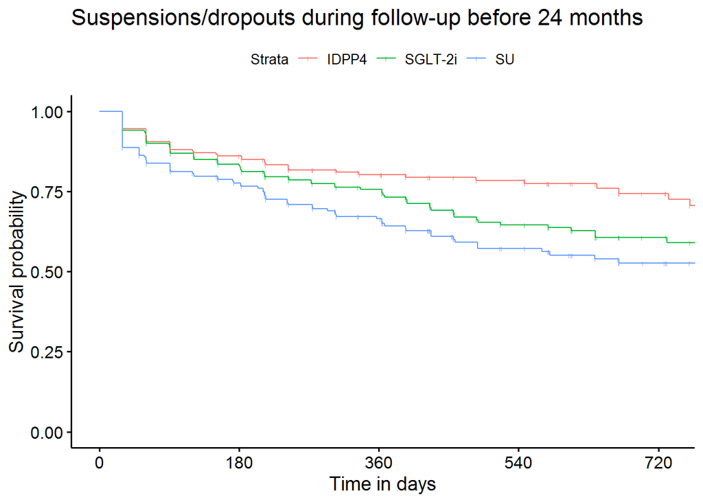

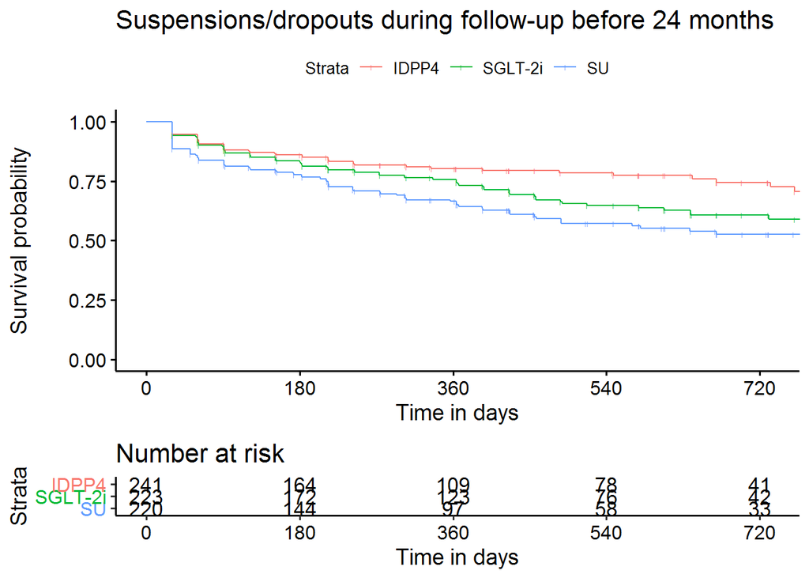

Summary descriptives table by groups of `temps_fins_stop’

|  | No event | Event | HR | p.ratio | p.overall |
| --- | --- | --- | --- | --- | --- |
|  | N=475 | N=209 |  |  |  |
| Group: |  |  |  |  | 0.001 |
| IDPP4 | 191 (40.2%) | 50 (23.9%) | Ref. | Ref. |  |
| ISGLT2 | 149 (31.4%) | 74 (35.4%) | 1.49 [1.04;2.14] | 0.029 |  |
| SU | 135 (28.4%) | 85 (40.7%) | 1.98 [1.40;2.81] | <0.001 |  |

### Resultado 5.

- To describe the relevant adverse reactions produced after the addition of an SU, an DPP-4i or an SGLT-2i in patients with DM2 treated with metformin and insufficient glycemic control.

Summary descriptives table by groups of `Group’

|  | [ALL] | IDPP4 | ISGLT2 | SU |
| --- | --- | --- | --- | --- |
|  | N=722 | N=247 | N=247 | N=228 |
| AMPUTACIONS: Yes | 1 (0.14%) | 0 (0.00%) | 1 (0.40%) | 0 (0.00%) |
| CETOACIDOSIS: No | 722 (100%) | 247 (100%) | 247 (100%) | 228 (100%) |
| Fractures: Yes | 23 (3.19%) | 10 (4.05%) | 6 (2.43%) | 7 (3.07%) |
| Gastrointes_EA: Yes | 65 (9.00%) | 23 (9.31%) | 19 (7.69%) | 23 (10.1%) |
| NEO_GASTROINT: Yes | 6 (0.83%) | 6 (2.43%) | 0 (0.00%) | 0 (0.00%) |
| Dermato_EA: Yes | 27 (3.74%) | 9 (3.64%) | 9 (3.64%) | 9 (3.95%) |
| Hepato EA: Yes | 9 (1.25%) | 2 (0.81%) | 4 (1.62%) | 3 (1.32%) |
| Hemato EA: No | 722 (100%) | 247 (100%) | 247 (100%) | 228 (100%) |
| Renals EA: Yes | 12 (1.66%) | 2 (0.81%) | 6 (2.43%) | 4 (1.75%) |
| GenitoUri EA: Yes | 71 (9.83%) | 20 (8.10%) | 28 (11.3%) | 23 (10.1%) |
| HIPOGLUCEMIES: Yes | 1 (0.14%) | 0 (0.00%) | 1 (0.40%) | 0 (0.00%) |

### Resultado 6.

- To describe the comorbidity profile and baseline clinical characteristics of patients with DM2 and insufficient control with metformin in monotherapy after addition of a treatment with SU, DPP-4i or SGLT-2i.
- Se ha considerado grupo con insuficiente control después de la addición, una HBA1C >=7% después del tratamiento antes de los 24 meses.

Comorbidity profile and baseline clinical characteristics by group

|  | [ALL] | IDPP4 | ISGLT2 | SU | p.overall |
| --- | --- | --- | --- | --- | --- |
|  | N=306 | N=94 | N=122 | N=90 |  |
| Sex: |  |  |  |  | 0.305 |
| M | 189 (61.8%) | 58 (61.7%) | 70 (57.4%) | 61 (67.8%) |  |
| F | 117 (38.2%) | 36 (38.3%) | 52 (42.6%) | 29 (32.2%) |  |
| Smoking habit: |  |  |  |  | 0.539 |
| No | 133 (43.8%) | 44 (47.3%) | 56 (46.3%) | 33 (36.7%) |  |
| Smoke | 59 (19.4%) | 15 (16.1%) | 23 (19.0%) | 21 (23.3%) |  |
| Former | 112 (36.8%) | 34 (36.6%) | 42 (34.7%) | 36 (40.0%) |  |
| Age | 60.5 (11.2) | 61.0 (11.7) | 60.5 (11.4) | 59.8 (10.4) | 0.744 |
| Age groups: |  |  |  |  | 0.264 |
| (-Inf,55] | 94 (30.7%) | 29 (30.9%) | 37 (30.3%) | 28 (31.1%) |  |
| (55,65] | 112 (36.6%) | 35 (37.2%) | 39 (32.0%) | 38 (42.2%) |  |
| (65,75] | 71 (23.2%) | 18 (19.1%) | 37 (30.3%) | 16 (17.8%) |  |
| (75, Inf] | 29 (9.48%) | 12 (12.8%) | 9 (7.38%) | 8 (8.89%) |  |
| Diabetes duration | 8.10 (7.63) | 7.52 (7.10) | 8.77 (7.45) | 7.79 (8.40) | 0.444 |
| HBA1C basal: (7, Inf] | 306 (100%) | 94 (100%) | 122 (100%) | 90 (100%) | . |
| HbA1C (%) | 8.85 (1.29) | 8.89 (1.19) | 8.85 (1.31) | 8.80 (1.39) | 0.901 |
| BMI | 32.2 (5.63) | 31.8 (5.07) | 32.7 (5.49) | 32.0 (6.33) | 0.460 |
| Sistolic Blood pressure baseline | 134 (14.2) | 132 (14.8) | 134 (14.5) | 134 (13.1) | 0.637 |
| Diastolic Blood pressure | 78.2 (9.85) | 78.4 (9.62) | 77.6 (10.1) | 79.0 (9.81) | 0.573 |
| Lipid profile- triglicerids | 211 (158) | 237 (214) | 196 (139) | 203 (103) | 0.148 |
| Total Cholesterol | 186 (43.7) | 186 (43.6) | 182 (40.7) | 191 (47.4) | 0.338 |
| LDL Cholesterol | 100 (33.1) | 98.6 (29.0) | 97.5 (35.0) | 106 (34.1) | 0.196 |
| HDL Cholesterol | 46.5 (13.6) | 44.3 (11.2) | 48.3 (14.7) | 46.2 (13.9) | 0.125 |
| Albumin / creatinine ratio | 99.9 (375) | 79.3 (347) | 158 (504) | 43.0 (84.1) | 0.185 |
| Glomerular filtration | 81.7 (12.7) | 82.3 (11.4) | 81.2 (13.0) | 81.6 (13.7) | 0.800 |
| Heart failure: |  |  |  |  | 0.688 |
| No | 290 (94.8%) | 89 (94.7%) | 117 (95.9%) | 84 (93.3%) |  |
| Yes | 16 (5.23%) | 5 (5.32%) | 5 (4.10%) | 6 (6.67%) |  |
| Peripheral vascular diseases: |  |  |  |  | 0.627 |
| No | 287 (93.8%) | 90 (95.7%) | 113 (92.6%) | 84 (93.3%) |  |
| Yes | 19 (6.21%) | 4 (4.26%) | 9 (7.38%) | 6 (6.67%) |  |
| AVC: |  |  |  |  | 0.222 |
| No | 282 (92.2%) | 90 (95.7%) | 109 (89.3%) | 83 (92.2%) |  |
| Yes | 24 (7.84%) | 4 (4.26%) | 13 (10.7%) | 7 (7.78%) |  |
| Ischemic heart disease: |  |  |  |  | 0.046 |
| No | 262 (85.6%) | 84 (89.4%) | 97 (79.5%) | 81 (90.0%) |  |
| Yes | 44 (14.4%) | 10 (10.6%) | 25 (20.5%) | 9 (10.0%) |  |
| Cardiovascular disease: |  |  |  |  | 0.086 |
| No | 236 (77.1%) | 79 (84.0%) | 87 (71.3%) | 70 (77.8%) |  |
| Yes | 70 (22.9%) | 15 (16.0%) | 35 (28.7%) | 20 (22.2%) |  |
| Diabetic neuropathy: |  |  |  |  | 0.172 |
| No | 296 (96.7%) | 93 (98.9%) | 115 (94.3%) | 88 (97.8%) |  |
| Yes | 10 (3.27%) | 1 (1.06%) | 7 (5.74%) | 2 (2.22%) |  |
| Diabetic retinopathy: |  |  |  |  | <0.001 |
| No | 272 (88.9%) | 89 (94.7%) | 95 (77.9%) | 88 (97.8%) |  |
| Yes | 34 (11.1%) | 5 (5.32%) | 27 (22.1%) | 2 (2.22%) |  |
| Hypertension: |  |  |  |  | 0.163 |
| No | 94 (30.7%) | 32 (34.0%) | 30 (24.6%) | 32 (35.6%) |  |
| Yes | 212 (69.3%) | 62 (66.0%) | 92 (75.4%) | 58 (64.4%) |  |
| Hyperlipidemia: |  |  |  |  | 0.870 |
| No | 105 (34.3%) | 31 (33.0%) | 44 (36.1%) | 30 (33.3%) |  |
| Yes | 201 (65.7%) | 63 (67.0%) | 78 (63.9%) | 60 (66.7%) |  |
| Acute / chronic pancreatitis: |  |  |  |  | 0.791 |
| No | 296 (96.7%) | 92 (97.9%) | 117 (95.9%) | 87 (96.7%) |  |
| Yes | 10 (3.27%) | 2 (2.13%) | 5 (4.10%) | 3 (3.33%) |  |
| COPD: |  |  |  |  | 0.674 |
| No | 281 (91.8%) | 87 (92.6%) | 110 (90.2%) | 84 (93.3%) |  |
| Yes | 25 (8.17%) | 7 (7.45%) | 12 (9.84%) | 6 (6.67%) |  |
| Renal insufficiency: |  |  |  |  | 0.557 |
| No | 286 (93.5%) | 89 (94.7%) | 115 (94.3%) | 82 (91.1%) |  |
| Yes | 20 (6.54%) | 5 (5.32%) | 7 (5.74%) | 8 (8.89%) |  |
| Relevant liver disease: |  |  |  |  | 0.659 |
| No | 294 (96.1%) | 90 (95.7%) | 116 (95.1%) | 88 (97.8%) |  |
| Yes | 12 (3.92%) | 4 (4.26%) | 6 (4.92%) | 2 (2.22%) |  |
| Mental disorders: |  |  |  |  | 0.690 |
| No | 254 (83.0%) | 77 (81.9%) | 104 (85.2%) | 73 (81.1%) |  |
| Yes | 52 (17.0%) | 17 (18.1%) | 18 (14.8%) | 17 (18.9%) |  |
| Mental dis. to physiological con.: |  |  |  |  | 0.294 |
| No | 305 (99.7%) | 94 (100%) | 122 (100%) | 89 (98.9%) |  |
| Yes | 1 (0.33%) | 0 (0.00%) | 0 (0.00%) | 1 (1.11%) |  |
| Comorbidities number | 2.03 (1.21) | 1.89 (1.05) | 2.16 (1.34) | 1.99 (1.16) | 0.247 |
| Comorbidities number: |  |  |  |  | 0.725 |
| >3 | 94 (30.7%) | 24 (25.5%) | 42 (34.4%) | 28 (31.1%) |  |
| 1-2 | 186 (60.8%) | 62 (66.0%) | 70 (57.4%) | 54 (60.0%) |  |
| None | 26 (8.50%) | 8 (8.51%) | 10 (8.20%) | 8 (8.89%) |  |
| situacio: |  |  |  |  | 0.025 |
| A | 303 (99.0%) | 94 (100%) | 122 (100%) | 87 (96.7%) |  |
| D | 3 (0.98%) | 0 (0.00%) | 0 (0.00%) | 3 (3.33%) |  |
| Dies entre data d’inclusió i data fi (Mort o 31/12/2017) | 672 (323) | 703 (424) | 660 (261) | 655 (274) | 0.526 |

- To describe the clinical characteristics of patients who have the best efficacy results (patients with a reduction of HbA1c of more than 0.5% and a weight reduction of at least 3% before the end of follow-up).
- Comparativa de características basales de pacientes que consiguen una reducción reduction de peso y HBA1C del 3% y de 0.5 unidades de HBA1c(%) en algun momento antes de los 24meses

### Resultado 7.

Clinical characteristics of patients who have the best results (Weight-HBA1C reduction vs No) before the end of follow-up

|  | No | Yes | p.overall |
| --- | --- | --- | --- |
|  | N=319 | N=117 |  |
| Sex: |  |  | 1.000 |
| M | 195 (61.1%) | 71 (60.7%) |  |
| F | 124 (38.9%) | 46 (39.3%) |  |
| Smoking habit: |  |  | 0.774 |
| No | 141 (44.5%) | 56 (47.9%) |  |
| Smoke | 62 (19.6%) | 23 (19.7%) |  |
| Former | 114 (36.0%) | 38 (32.5%) |  |
| Age | 60.8 (11.4) | 61.0 (10.6) | 0.877 |
| Age groups: |  |  | 0.979 |
| (-Inf,55] | 92 (28.8%) | 32 (27.4%) |  |
| (55,65] | 113 (35.4%) | 44 (37.6%) |  |
| (65,75] | 83 (26.0%) | 30 (25.6%) |  |
| (75, Inf] | 31 (9.72%) | 11 (9.40%) |  |
| Diabetes duration | 7.64 (7.15) | 7.29 (6.41) | 0.629 |
| HBA1C basal: (7, Inf] | 319 (100%) | 117 (100%) | . |
| HbA1C (%) | 8.65 (1.42) | 8.79 (1.26) | 0.318 |
| BMI | 32.5 (5.71) | 33.2 (5.01) | 0.220 |
| Sistolic Blood pressure baseline | 133 (13.6) | 132 (14.5) | 0.283 |
| Diastolic Blood pressure | 77.7 (9.51) | 78.1 (8.76) | 0.666 |
| Lipid profile- triglicerids | 205 (154) | 213 (160) | 0.663 |
| Total Cholesterol | 187 (41.0) | 187 (39.6) | 0.979 |
| LDL Cholesterol | 103 (33.6) | 102 (33.2) | 0.805 |
| HDL Cholesterol | 46.1 (12.7) | 47.0 (13.0) | 0.521 |
| Albumin / creatinine ratio | 88.2 (349) | 48.0 (115) | 0.146 |
| Glomerular filtration | 82.0 (12.5) | 82.4 (10.4) | 0.742 |
| Heart failure: |  |  | 1.000 |
| No | 306 (95.9%) | 112 (95.7%) |  |
| Yes | 13 (4.08%) | 5 (4.27%) |  |
| Peripheral vascular diseases: |  |  | 0.713 |

[output cut: 51 more lines]